# Business Forecationg Project

Laabidi Nadine

09/01/2023

## Goal

The goal of this project is to build an ARIMA model, with which we can forecast the retail price of Diesel using the series past values.

## The packages used

- TSA: time series analysis, we couldn’t upload it so we uploaded the R code of the functions as a source.
- TSstudio: this package provides a set of tools descriptive and predictive analysis of time series data. we used from it the function ts_split in order to split the data into train and test set
- forecast: it provides you with Methods and tools for displaying and analysing univariate time series forecasts including exponen-tial smoothing via state space models and automatic ARIMA modelling. we used from it the boxcox.lambda, the acf, the pacf and the accruracy functions to measure the accuracy of our forecast.
- tseries: Time series analysis and computational finance, we used it for the adf test

## Dataset Overview

```r
rm(list=ls())
data<-read.csv("project.csv",  sep=",", dec="." , header=T)
summary(data)
```

```
##      Date           U.S..No.2.Diesel.Retail.Prices..Dollars.per.Gallon.
##  Length:313         Min.   :0.959
##  Class :character   1st Qu.:1.348
##  Mode  :character   Median :2.467
##                     Mean   :2.370
##                     3rd Qu.:3.069
##                     Max.   :4.703
```

the source of our dataset is the **U.S. Energy Information Administration (EIA)** which is a principal agency of the U.S. Federal Statistical System responsible for collecting, analyzing, and disseminating energy information to promote sound policymaking, efficient markets, and public understanding of energy and its interaction with the economy and the environment.

The dataset we are working on presents **the US Diesel retail prices** from **May 1994 until May 2020** we have 313 observations lying between *0.959 and 4.703*

## ARIMA model selection

### converting the dataset into a time series

we use the function ts() to convert the original dataset into a time series. the frequency is equal to 12 because it’s a monthly dataset starting from May 1994

```r
data=data[,-1]
project  <- ts(data, frequency=12, start=c(1994,5))
project
```

```
##        Jan   Feb   Mar   Apr   May   Jun   Jul   Aug   Sep   Oct   Nov   Dec
## 1994                         1.100 1.103 1.110 1.123 1.125 1.122 1.131 1.113
## 1995 1.098 1.088 1.088 1.104 1.126 1.120 1.100 1.105 1.119 1.115 1.120 1.130
## 1996 1.145 1.145 1.183 1.275 1.273 1.201 1.176 1.201 1.265 1.323 1.323 1.309
## 1997 1.291 1.280 1.229 1.212 1.196 1.173 1.151 1.165 1.160 1.183 1.192 1.166
## 1998 1.120 1.084 1.063 1.067 1.069 1.041 1.029 1.007 1.024 1.039 1.022 0.973
## 1999 0.967 0.959 0.997 1.079 1.073 1.074 1.122 1.172 1.215 1.228 1.263 1.292
## 2000 1.356 1.461 1.479 1.422 1.420 1.421 1.434 1.466 1.637 1.637 1.621 1.565
## 2001 1.524 1.492 1.399 1.422 1.496 1.482 1.375 1.390 1.495 1.348 1.259 1.167
## 2002 1.153 1.152 1.230 1.309 1.305 1.286 1.299 1.328 1.411 1.462 1.420 1.429
## 2003 1.488 1.654 1.708 1.533 1.451 1.424 1.435 1.487 1.467 1.481 1.482 1.490
## 2004 1.551 1.582 1.629 1.692 1.746 1.711 1.739 1.833 1.917 2.134 2.147 2.009
## 2005 1.959 2.027 2.214 2.292 2.199 2.290 2.373 2.500 2.819 3.095 2.573 2.443
## 2006 2.467 2.475 2.559 2.728 2.897 2.898 2.934 3.045 2.783 2.519 2.545 2.610
## 2007 2.485 2.488 2.667 2.834 2.796 2.808 2.868 2.869 2.953 3.075 3.396 3.341
## 2008 3.308 3.377 3.881 4.084 4.425 4.677 4.703 4.302 4.024 3.576 2.876 2.449
## 2009 2.292 2.195 2.092 2.220 2.227 2.529 2.540 2.634 2.626 2.672 2.792 2.745
## 2010 2.845 2.785 2.915 3.059 3.069 2.948 2.911 2.959 2.946 3.052 3.140 3.243
## 2011 3.388 3.584 3.905 4.064 4.047 3.933 3.905 3.860 3.837 3.798 3.962 3.861
## 2012 3.833 3.953 4.127 4.115 3.979 3.759 3.721 3.983 4.120 4.094 4.000 3.961
## 2013 3.909 4.111 4.068 3.930 3.870 3.849 3.866 3.905 3.961 3.885 3.839 3.882
## 2014 3.893 3.984 4.001 3.964 3.943 3.906 3.884 3.838 3.792 3.681 3.647 3.411
## 2015 2.997 2.858 2.897 2.782 2.888 2.873 2.788 2.595 2.505 2.519 2.467 2.310
## 2016 2.143 1.998 2.090 2.152 2.315 2.423 2.405 2.351 2.394 2.454 2.439 2.510
## 2017 2.580 2.568 2.554 2.583 2.560 2.511 2.496 2.595 2.785 2.794 2.909 2.909
## 2018 3.018 3.046 2.988 3.096 3.244 3.253 3.233 3.218 3.262 3.365 3.300 3.123
## 2019 2.980 2.997 3.076 3.121 3.161 3.089 3.045 3.005 3.016 3.053 3.069 3.055
## 2020 3.048 2.910 2.729 2.493 2.392
```

### splitting the dataset into training set and testing set

the function *ts_split* is used to Split a Time Series Object into Training and Testing Partitions

```r
library (TSstudio)
split_project <- ts_split(ts.obj = project, sample.out = 63)
training <- split_project$train
testing <- split_project$test
length(training)
```

```
## [1] 250
```

```r
length(testing)
```

```
## [1] 63
```

The training set incorporates 250 observations equivalent to 80% of the total observation while the testing set includes 63 observations equivalent to 20% of the total observations.

#### plotting the data

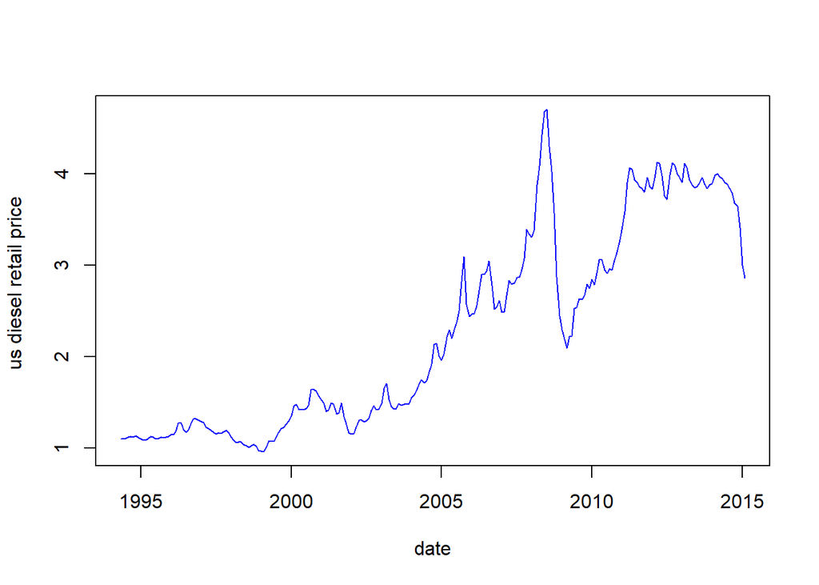

```r
plot(training,ylab="us diesel retail price ",xlab="date",  col= 'blue', type="l")
```

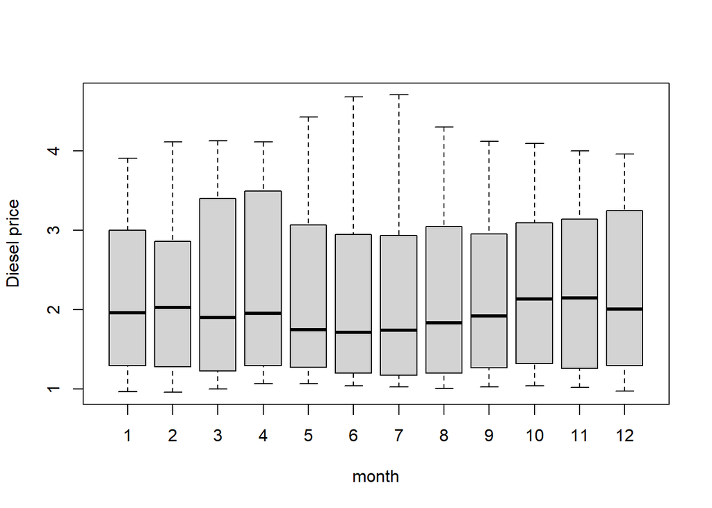

```r
boxplot (training~ cycle(training), xlab="month", ylab="Diesel price")
```

At a first glance we can see that the data exhibits an upward trend with the presence of an outlier at year 2008.

the following boxplot shows that the mean is not constant over time thus it’s a clear evidence that the series is **non-stationary**.

### computing lambda for transformation

```r
library(forecast)
BoxCox.lambda(training,  lower = -2, upper = 2)
```

```
## [1] -0.6716669
```

lambda is close to -0.5, in this case we ought to use the inverse square but it is hard to rescale it when making the forecast so there will be no transformation.

**NB:** the BoxCox.ar function didn’t work for us so we used the BoxCox.lambda function which takes the time series of class ts as an input and gives a number indicating the Box-Cox transformation parameter ,which is lambda , as an output.

### plotting the ACF, the PACF

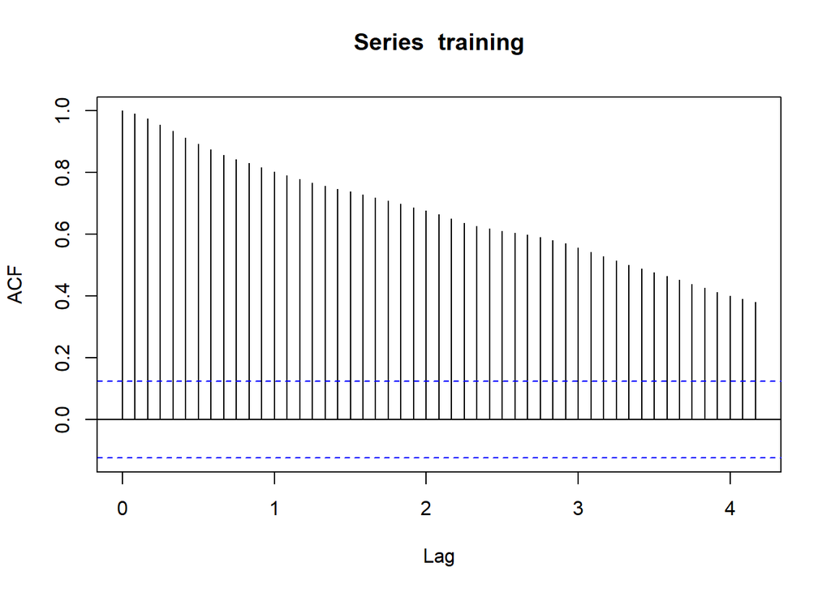

```r
acf(training, lag=50)
```

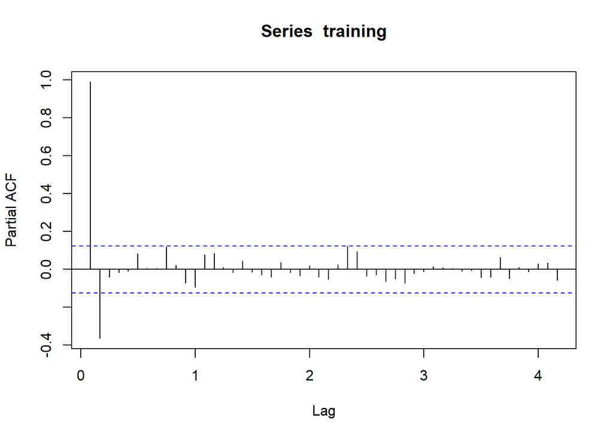

```r
pacf(training, lag=50)
```

The autocorrelation function plot shows a very slow decay which is typical of a nonstationary time series, meaning that the mean and the varinace depend on time.

let’s confirm that !

### stationarity test

To check for stationarity, we do the **Augmented Dickey Fuller test (ADF Test)**

H0: the series is non-stationary  
H1: the series is stationary

```r
library(tseries)
adf.test(training , alternative=c("stationary", "explosive"))
```

```
##
##  Augmented Dickey-Fuller Test
##
## data:  training
## Dickey-Fuller = -3.2302, Lag order = 6, p-value = 0.08332
## alternative hypothesis: stationary
```

the p-value is greater than 5% so we fail to reject H0  
the series is non-stationary and we need to make the first difference

### 1st difference stationarity test

```r
library(tseries)
diff_training<- diff(training)
adf.test(diff_training, alternative=c("stationary", "explosive"))
```

```
##
##  Augmented Dickey-Fuller Test
##
## data:  diff_training
## Dickey-Fuller = -5.9636, Lag order = 6, p-value = 0.01
## alternative hypothesis: stationary
```

the p-value is less than 5% so we reject H0 we have a stationary time series, now let’s examinate the plots !

### plotting the series after the first difference

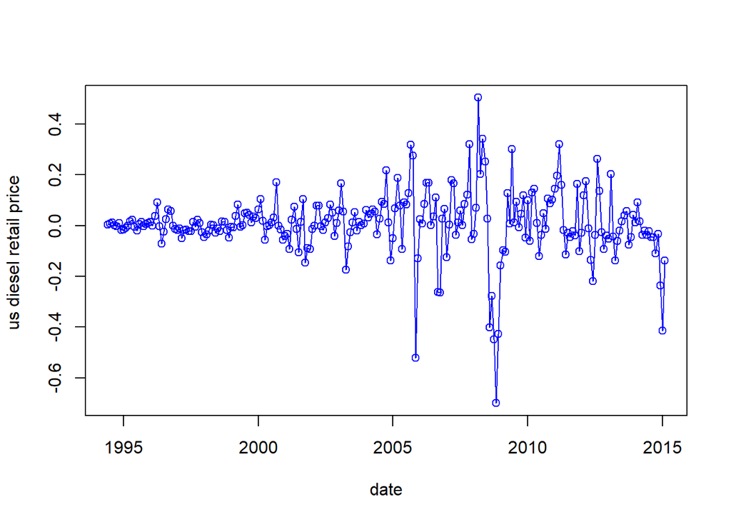

```r
plot(diff_training,ylab="us diesel retail price ",xlab="date", col="blue", type="o")
```

As we can see making the first difference helped us stabilise the mean of our time series and thus reduced the trend although we still have some outliers.

### plotting the ACF, PACF and EACF of the differenced dataset

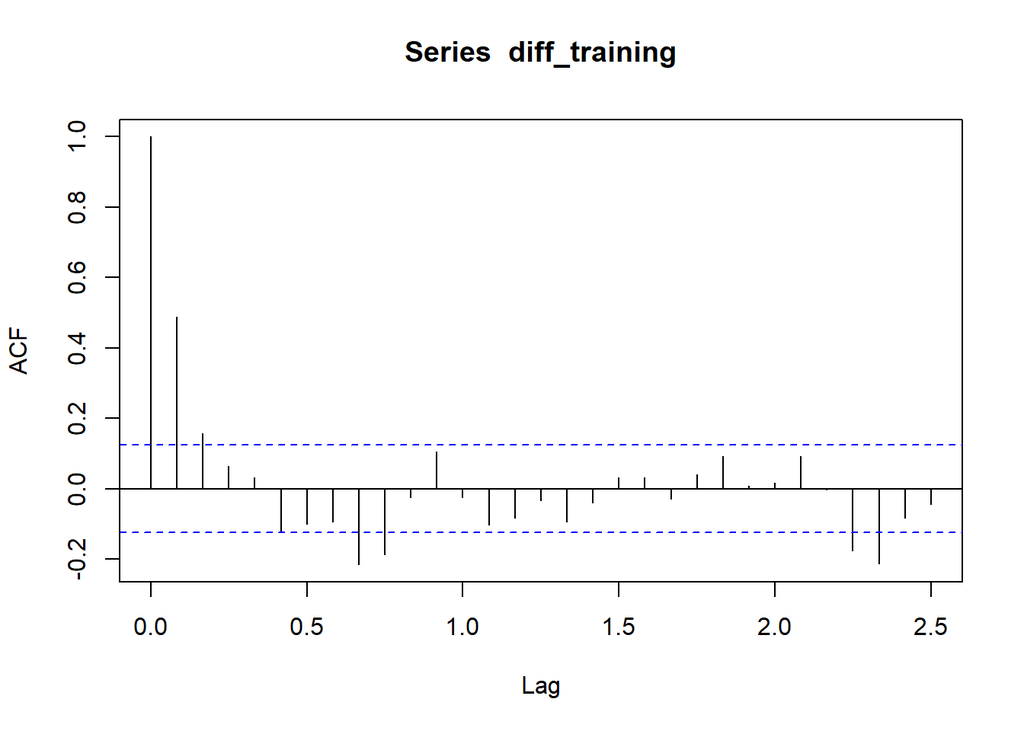

```r
source("eacf.R")
acf(diff_training, lag=30)
```

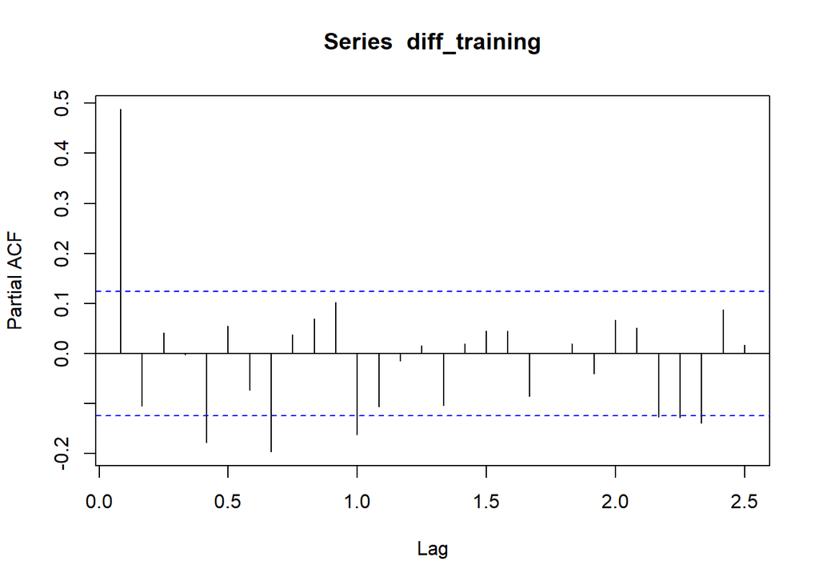

```r
pacf(diff_training, lag=30)
```

```r
eacf(diff_training)
```

```
## AR/MA
##   0 1 2 3 4 5 6 7 8 9 10 11 12 13
## 0 x x o o o o o x x o o  o  o  o
## 1 x o o o x o o x x o o  o  o  o
## 2 x o o o x o o x o o o  x  o  o
## 3 o o o x x o o x o o o  o  o  o
## 4 o x x o o o o x o o x  o  o  o
## 5 x x x o o o o x o o x  o  o  x
## 6 x o x o x o o x o o o  o  o  o
## 7 x x x x x x x x o o o  o  o  o
```

according to the PACF plot, we have two possible values of p which are 0 and 1

Thus the ACF and PACF give us two candidate models which are ARIMA(1,1,0) and ARIMA(0,1,0)

now for the **EACF** we look for the corners formed by the x’s from the bottom right side moving towards the top left. In our case, it indicates the possibility of an ARIMA (1,1,1)

all in all, we have THREE candidate models and we need now to make the estimation to be able to choose the final one.

### Making the estimation & choosing the appropriate model

we are going to use the likelyhood method as it’s the most commonly used technique, Nonetheless there are other methods like the method of moments and the least square estimation we can also use to estimate.

- Testing the ARIMA (0,1,0) model

```r
source("arima.R")
arima(training,order=c(0,1,0) ,method='ML')
```

```
##
## Call:
## arima(x = training, order = c(0, 1, 0), method = "ML")
##
##
## sigma^2 estimated as 0.01631:  log likelihood = 159.13,  aic = -318.26
```

The white noise process suggests that the fitted model is

Y(t)-Y(t-1)= e(t)

- Testing the ARIMA (1,1,0) model

```r
source("arima.R")
arima(training,order=c(1,1,0) ,method='ML')
```

```
##
## Call:
## arima(x = training, order = c(1, 1, 0), method = "ML")
##
## Coefficients:
##          ar1
##       0.4900
## s.e.  0.0551
##
## sigma^2 estimated as 0.01238:  log likelihood = 193.31,  aic = -384.61
```

The ARIMA(1,1,0) suggests that the fitted model is

Y(t)-Y(t-1)=0.4900Y(t-1)+e(t)

the ML phi estimate is equal to 0.4900 which is significantly different from zero

The white noise variance estimate is equal to 0.01238 and the aic is equal to -384.61

- Testing the ARIMA (1,1,1) model

```r
source("arima.R")
arima(training,order=c(1,1,1), method='ML')
```

```
##
## Call:
## arima(x = training, order = c(1, 1, 1), method = "ML")
##
## Coefficients:
##          ar1     ma1
##       0.3338  0.2064
## s.e.  0.1147  0.1179
##
## sigma^2 estimated as 0.01225:  log likelihood = 194.6,  aic = -385.2
```

Y(t)-Y(t-1)= 0.3338Y(t-1)+ 0.2064(e(t-1))+e(t)

The white noise variance estimate is equal to 0.01225 and the aic is equal to -385.2

## Forecasting

Now we will use the predict function to display the predictions for the last 20% of our dataset and compare it with the actual data (testing set)

```r
testing
```

```
##        Jan   Feb   Mar   Apr   May   Jun   Jul   Aug   Sep   Oct   Nov   Dec
## 2015             2.897 2.782 2.888 2.873 2.788 2.595 2.505 2.519 2.467 2.310
## 2016 2.143 1.998 2.090 2.152 2.315 2.423 2.405 2.351 2.394 2.454 2.439 2.510
## 2017 2.580 2.568 2.554 2.583 2.560 2.511 2.496 2.595 2.785 2.794 2.909 2.909
## 2018 3.018 3.046 2.988 3.096 3.244 3.253 3.233 3.218 3.262 3.365 3.300 3.123
## 2019 2.980 2.997 3.076 3.121 3.161 3.089 3.045 3.005 3.016 3.053 3.069 3.055
## 2020 3.048 2.910 2.729 2.493 2.392
```

```r
min (testing)
```

```
## [1] 1.998
```

```r
max (testing)
```

```
## [1] 3.365
```

```r
source("predict.TAR.R")
model=arima(training, order=c(1,1,1), method='ML')
predict_testing<- predict(model, n.ahead=63)
round (predict_testing$pred,4)
```

```
##         Jan    Feb    Mar    Apr    May    Jun    Jul    Aug    Sep    Oct
## 2015               2.8237 2.8122 2.8084 2.8071 2.8067 2.8066 2.8065 2.8065
## 2016 2.8065 2.8065 2.8065 2.8065 2.8065 2.8065 2.8065 2.8065 2.8065 2.8065
## 2017 2.8065 2.8065 2.8065 2.8065 2.8065 2.8065 2.8065 2.8065 2.8065 2.8065
## 2018 2.8065 2.8065 2.8065 2.8065 2.8065 2.8065 2.8065 2.8065 2.8065 2.8065
## 2019 2.8065 2.8065 2.8065 2.8065 2.8065 2.8065 2.8065 2.8065 2.8065 2.8065
## 2020 2.8065 2.8065 2.8065 2.8065 2.8065
##         Nov    Dec
## 2015 2.8065 2.8065
## 2016 2.8065 2.8065
## 2017 2.8065 2.8065
## 2018 2.8065 2.8065
## 2019 2.8065 2.8065
## 2020
```

```r
min(predict_testing$pred)
```

```
## [1] 2.806508
```

```r
max(predict_testing$pred)
```

```
## [1] 2.823697
```

the actual data are within an interval from 1.998 to 3.365 while the predicted data fell within an interval from 2.806508 to 2.823697

now let’s check the plot of our series, forecast,limits and actual values!

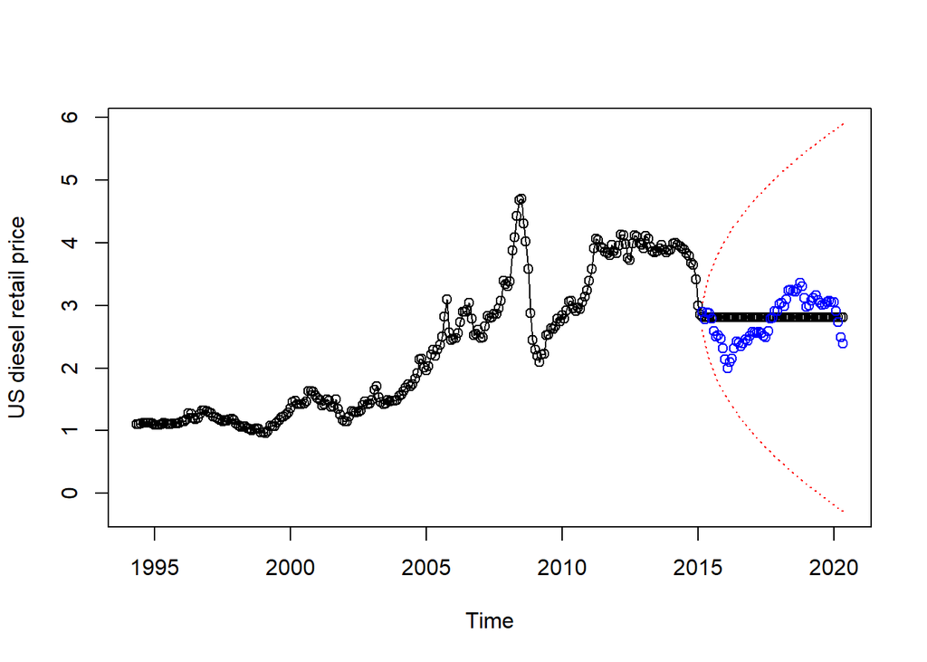

```r
source ("plot.Arima.R")
plot(model, n.ahead=63, ylab= 'US diesel retail price', col="red", type="b")
lines(testing, col="blue", type="b")
```

- the red area presents 95% forecast limits
- the blue graph presents the actual values of the series
- the black line is the forecast. it has this shape because as shown in the table of the predicted values above they are close to each other in the values. it is also the same for the actual values

As we can see the actual values fell within the forecast limits.

### Forecast accuarcy

The accuracy function returns the range of summary measures of the forecast accuracy. It take as inputs the vector containing forecasts and the one containing the actual values

```r
library(forecast)
accuracy(predict_testing$pred, testing)
```

```
##                   ME      RMSE       MAE       MPE    MAPE     ACF1 Theil's U
## Test set -0.03664729 0.3423696 0.2977749 -2.954757 11.2963 0.952254  3.893818
```

The measures calculated are:

*The MAPE* is one the most accurate and common forecast accuracy error measurement, with our series it is equal to 11.2963% it is between 10% and 20% thus our **forecast is good**